[figure not shown]

# Regression Tutorial SWDB 2022

### Friday, August 26, 2022

Machine learning has many canonical problem types that we will discuss in these tutorials. These include Regression, Classification, Clustering, and Dimension Reduction. This tutorial is focused on Regression.

Regression is an example of a Supervised Learning problem. In a regression problem, we are given $N$ pairs of data points $(\vec{x}_i, y_i)$ where $i \in [1,N]$. We want to develop a function $f(\vec{x})$ such that $f(\vec{x}_i)\approx y_i$ for each pair of points in the data set. The purpose of this function is to provide us with a model of how the data points $\vec{x}_i$ affect $y_i$. This allows us to learn the degree to which $\vec{x}_i$ has predictive power of $y_i$ and can tell you whether and how these data are correlated with each other.

The simplest regression problem is linear regression, in which we try to create the function $f$ by linearly combining a set of functions that act on the points $x$. $f(\vec{x}_i) = \sum_j w_j \phi(\vec{x}_i)$ The functions $\phi(\vec{x})$ are chosen according to the analysis. They are often called "features". The coefficients $w_j$ are called "weights". You may be familiar with a simple version of linear regression, where the functions $\phi$ are chosen to be the identity and a constant. When the input space is also one dimensional, our function to fit becomes: $f(x) = w x + b$

This problem is solved by minimizing an "error function" function $E$ such that $f$ most closely approximates the data points $y_i$ on the inputs $\vec{x}_i$. This error function is simply the squared difference between $y$ and $f(\vec{x})$. $E = \frac{1}{2} \sum_i \left | y_i - f\left ( \vec{x}_i \right ) \right |^2 = \frac{1}{2} \sum_i \left | y_i - \sum_j w_j \phi (\vec{x}_i ) \right |^2 $

This particular problem has an exact analytic solution that is easy to implement, but in this tutorial, we will look at how to perform regression using the `scikit-learn` Python package. `scikit-learn` has many regression algorithms in common use built in, most of which do not have simple analytic solutions. In addition, other packages have adopted the `scikit-learn` style interface. One advantage of this is that multiple algorithms can be deployed with the same code. The `scikit-learn` website: http://scikit-learn.org/stable/

```python
# import general packages we'll need in this tutorial

import numpy as np
import matplotlib.pyplot as plt
import os
```

We're going to provide a simple example with fake data and then use the same model to fit data from the Brain Observatory. We will attempt to model the data using an $n$th order polynomial of a single variable:

$f_n(x) = \sum_{i=0}^n a_i x^i$

i.e.

$f_1(x) = a_0 + a_1 x$

$f_2(x) = a_0 + a_1 x + a_2x^2$

$\dots$

First we generate some example data. This will be the true model of the data. (In a real problem, we won't know this function; we're trying to fit it.)

$F(x) = sin(2\pi x)$

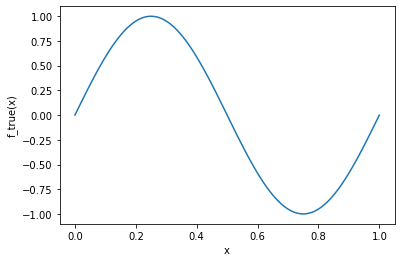

```python
x_bins = np.linspace(0,1.0, 100)

def f_true(xt):
    return np.sin(2.0*np.pi*xt)

fig, ax = plt.subplots()
ax.plot(x_bins, f_true(x_bins))
ax.set_ylabel('f_true(x)')
ax.set_xlabel('x')
```

Now we generate some 'data' from this function.

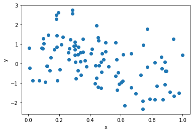

```python
# so that everyone gets the same random data!
rand_seed = 6942069
np.random.seed(rand_seed)

n = 100

x = np.sort(np.random.random(n))
y = f_true(x) + 1.0*np.random.normal(size=n)

fig, ax = plt.subplots()
ax.plot(x, y, 'o')
ax.set_ylabel('y')
ax.set_xlabel('x')
```

## Fitting a first order polynomial

Before we fit any models, we need to separate the data into train, validate, and test sets. This is so that we can train the model (train), perform comparisons between different models and select the most appropriate one (validate), and test the performance of our finalmodel (test).

`scikit-learn` has a function we can use called `train_test_split`. We use this function twice in order to generate a validation set. Note how we split the data in half to create our training set, and split the remainder in half again to create the validation and testing sets.

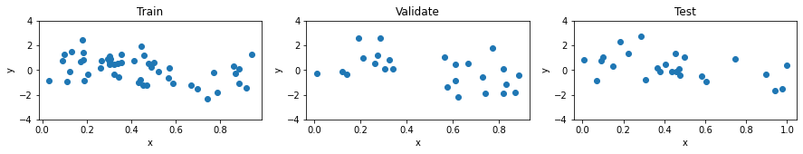

```python
from sklearn.model_selection import train_test_split

x_train, x_validate, y_train, y_validate = train_test_split(x, y, train_size=0.5, random_state=rand_seed)
x_validate, x_test, y_validate, y_test = train_test_split(x_validate, y_validate, test_size=0.5, random_state=rand_seed)

fig, ax = plt.subplots(1,3, figsize=(15,2))
ax[0].plot(x_train, y_train, 'o')
ax[1].plot(x_validate, y_validate, 'o')
ax[2].plot(x_test, y_test, 'o')

ax[0].set_title('Train')
ax[1].set_title('Validate')
ax[2].set_title('Test')

for i in range(3):
    ax[i].set_ylim(-4, 4)
    ax[i].set_xlabel('x')
    ax[i].set_ylabel('y')
```

In ordert to fit the model, we need to create the object that will manage the fitting. We are going to use the `LinearRegression` model from `sklearn.linear_model`. Fitting works by calling the `fit` method with the data.

```python
from sklearn.linear_model import LinearRegression
```

We reshape `x` in the `fit` method because it expects a two dimensional array of shape (samples, dimensions).

```python
regression = LinearRegression()
regression.fit(x_train.reshape(-1, 1), y_train)
```

```
LinearRegression()
```

Now we compare the result to the validation set. Calling the "predict" method in our linear regression object will return $f(x)$ given the passed $x$. In other words, it will predict what are the data points $y$ you ought to observe given the data points $x$. We will plot the points predicted by the model together with the points in our validation set to see how well the model performed.

```
(-4.0, 4.0)
```

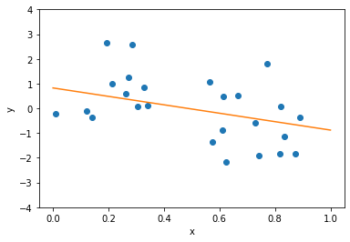

```python
fig, ax = plt.subplots()
ax.plot(x_validate, y_validate, 'o')
predicted_y = regression.predict(x_bins.reshape(-1,1))
ax.plot(x_bins.reshape(-1,1), predicted_y, '-')
ax.set_ylabel('y')
ax.set_xlabel('x')
ax.set_ylim(-4,4)
```

That's ok, but we could clearly do better. Let's try multiple orders of polynomials so that we can compare them with the validation set.

We define a function `nth_polynomial` in order to create input data whose rows are data points and whose columns are the terms in the polynomial ($x$, $x^2$, $x^3$, $\dots$)

```python
def nth_polynomial(x, n):
    return np.stack([x**i for i in range(1, n+1)], axis=1)
```

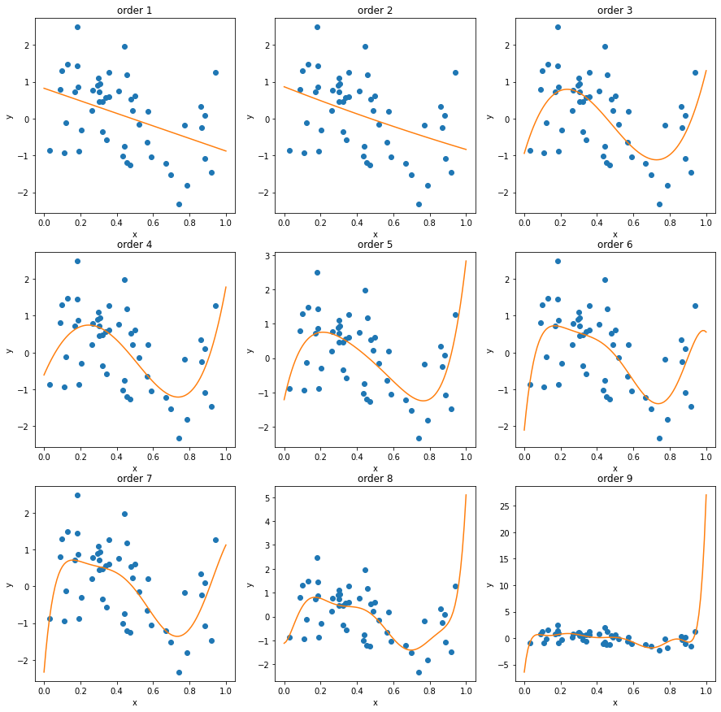

```python
max_order = 9

regression_list = [LinearRegression() for ind in range(max_order)]
for ind, regression in enumerate(regression_list):
    x_nth = nth_polynomial(x_train, ind+1)
    regression.fit(x_nth, y_train)

fig, ax = plt.subplots(3,3, figsize=(15,15))

for ind, regression in enumerate(regression_list):
    xi = ind%3
    yi = ind//3
    x_nth = nth_polynomial(x_bins, ind+1)
    ax[yi, xi].plot(x_train, y_train, 'o')
    ax[yi, xi].plot(x_bins, regression.predict(x_nth))
    ax[yi, xi].set_xlabel('x')
    ax[yi, xi].set_ylabel('y')
    ax[yi, xi].set_title('order '+str(ind+1))
```

Here are the models of various degree plotted against the training set. It seems like the fit improves as the order improves, but beware! Using a model with too many parameters for your data may improve the fit for your training set, but your model may become so finely tuned to the training set in particular that it is not generalizable. This is a problem known as "overfitting."

To demonstrate, we plot these models against the validation set.

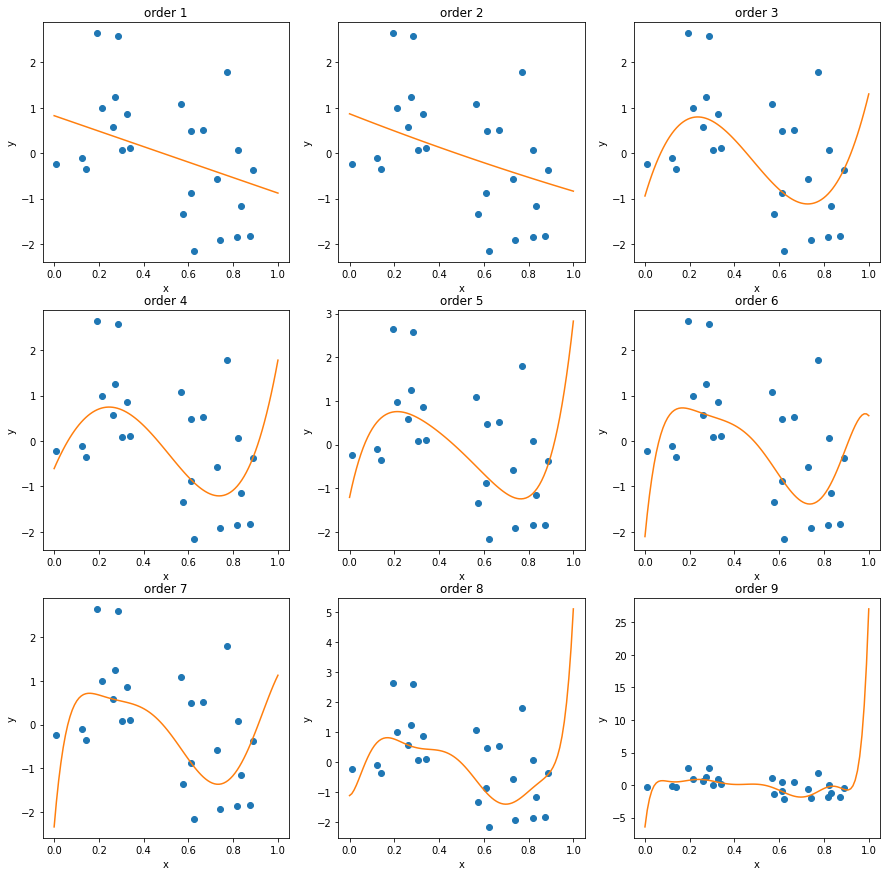

```python
fig, ax = plt.subplots(3,3, figsize=(15,15))

for ind, regression in enumerate(regression_list):
    xi = ind%3
    yi = ind//3
    x_nth = nth_polynomial(x_bins, ind+1)
    ax[yi, xi].plot(x_validate, y_validate, 'o')
    ax[yi, xi].plot(x_bins, regression.predict(x_nth))
    ax[yi, xi].set_xlabel('x')
    ax[yi, xi].set_ylabel('y')
    ax[yi, xi].set_title('order '+str(ind+1))
```

To quantify how well each of these models performs, we calculate the $R^2$ of the fit by calling the "score" method for each regression.

```
Best model is order:  3
```

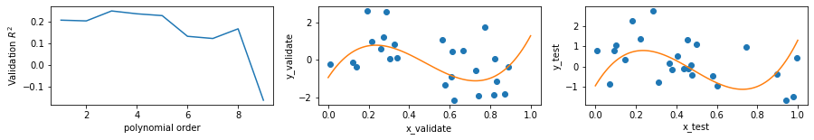

```python
R2_vals = []

for ind, regression in enumerate(regression_list):
    x_nth = nth_polynomial(x_validate, ind+1)
    R2 = regression.score(x_nth, y_validate)
    R2_vals.append(R2)

order = np.arange(1,max_order+1)
fig, ax = plt.subplots(1,3, figsize=(15,2))
ax[0].plot(order, R2_vals)
ax[0].set_ylabel('Validation $R^2$')
ax[0].set_xlabel('polynomial order')

best_model_index = np.argmax(R2_vals)
regression_best = regression_list[best_model_index]

ax[1].plot(x_validate, y_validate, 'o')
x_nth = nth_polynomial(x_bins, best_model_index+1)
ax[1].plot(x_bins, regression_best.predict(x_nth))
ax[1].set_ylabel('y_validate')
ax[1].set_xlabel('x_validate')


ax[2].plot(x_test, y_test, 'o')
ax[2].plot(x_bins, regression_best.predict(x_nth))
ax[2].set_ylabel('y_test')
ax[2].set_xlabel('x_test')

print("Best model is order:  {}".format(best_model_index+1))
```

## Cross validation

We just used our "validation" data set to try to determine how well each of our models generalizes to other data, but in fact, `scikit-learn` has built-in functions to make validation very simple! We can use our training data set to perform **cross validation**, where our model is fit multiple times on different subsets of the training data and the performance is compared across all subsets. This is similar to what we did above when we compared the training data to the validation data, and allows us to measure how consistent our model is.

Here, we perform cross validation with the functions `cross_validate` and `KFold`. `cross_validate` performs cross validation and returns a dictionary of scores over folds. `KFold` provides an iterator that produces indices that split the data into train and test folds.

In the following, we'll ignore the data set we labeled "validate" above. In fact, this additional data set is unneccessary as data used for validation is part of the cross validation separation of the training set in the code below. In the future, you only need to split your data into training and testing sets! (That said, it is still worthwhile to have a separate validation and testing set if you plan to test many different models or tweak your model a lot before finalizing.)

[The sklearn website](https://scikit-learn.org/stable/modules/cross_validation.html) is an excellent resource for explaining why cross validation is important, how it is implemented, and the various methods available.

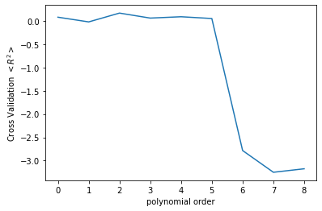

```python
from sklearn.model_selection import cross_validate
cv_mean_error = np.zeros_like(regression_list)

for ind, regression in enumerate(regression_list):
    x_nth = nth_polynomial(x_train, ind+1)
    cv_dict = cross_validate(regression, x_nth, y_train, cv=4)
    cv_mean_error[ind] = np.mean(cv_dict['test_score'])

fig, ax = plt.subplots()
ax.plot(cv_mean_error)
ax.set_ylabel('Cross Validation $<R^2>$')
ax.set_xlabel('polynomial order')
```

We can do the same analysis with `KFold`.

```python
from sklearn.model_selection import KFold
```

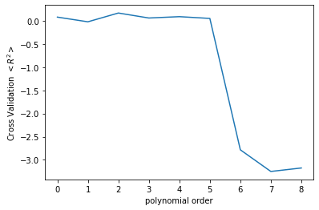

```python
folds = KFold(n_splits=4)

scores = np.zeros_like(regression_list)

for ind, regression in enumerate(regression_list):
    scores_temp = []
    for train, test in folds.split(x_train):
        x_nth = nth_polynomial(x_train[train], ind+1)
        regression.fit(x_nth, y_train[train])
        x_nth = nth_polynomial(x_train[test], ind+1)
        scores_temp.append(regression.score(x_nth, y_train[test]))
    scores[ind] = np.mean(scores_temp)


fig, ax = plt.subplots()
ax.plot(scores)
ax.set_ylabel('Cross Validation $<R^2>$')
ax.set_xlabel('polynomial order')
# ax.set_ylim(-0.25, 0.25)
```

Now that we know the best model, we can apply it to the test data.

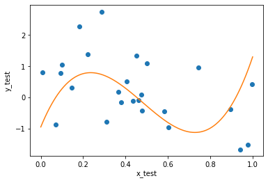

```python
best_model_index = np.argmax(scores)
regression_best = regression_list[best_model_index]
x_nth = nth_polynomial(x_train, best_model_index+1)
regression_best.fit(x_nth, y_train)

fig, ax = plt.subplots()
ax.plot(x_test, y_test, 'o')
x_nth = nth_polynomial(x_bins, best_model_index+1)
ax.plot(x_bins, regression_best.predict(x_nth))
ax.set_ylabel('y_test')
ax.set_xlabel('x_test')
```

## Regressing neuronal data

Now let's try a simple example with the Allen Brain Observatory Visual Behavior Dataset. We will try regressing the neural activity in the midbrain reticular nucleus (MRN) against the running speed of the animal.

```python
import allensdk
from allensdk.brain_observatory.\
    behavior.behavior_project_cache.\
    behavior_neuropixels_project_cache \
    import VisualBehaviorNeuropixelsProjectCache
import os
import platform
platstring = platform.platform()

data_dirname = 'visual-behavior-neuropixels'
use_static = False
if 'Darwin' in platstring or 'macOS' in platstring:
    # macOS
    data_root = "/Volumes/Brain2022/"
elif 'Windows'  in platstring:
    # Windows (replace with the drive letter of USB drive)
    data_root = "E:/"
elif ('amzn' in platstring):
    # then on AWS
    data_root = "/data/"
    data_dirname = 'visual-behavior-neuropixels-data'
    use_static = True
else:
    # then your own linux platform
    # EDIT location where you mounted hard drive
    data_root = "/media/$USERNAME/Brain2022/"

# get the cache location
cache_dir = os.path.join(data_root, data_dirname)


#cache = VisualBehaviorNeuropixelsProjectCache.from_s3_cache(cache_dir=cache_dir)
cache = VisualBehaviorNeuropixelsProjectCache.from_local_cache(
            cache_dir=cache_dir, use_static_cache=use_static)
```

We need to find which units have the sessions we are interested in, so we will need the units and sessions tables. We're just going to grab the session containing the most MRN units, though feel free to substitute a different brain region if you're curious!

```python
units_table = cache.get_unit_table()
ecephys_sessions_table = cache.get_ecephys_session_table()

# First, we want to find a "Good" Session to look at;
structure = 'MRN'
unit_by_session = units_table.join(ecephys_sessions_table,on = 'ecephys_session_id')
unit_in = unit_by_session[unit_by_session['structure_acronym']==structure]

unit_count = unit_in.groupby(["ecephys_session_id"]).count()
session_with_most_in_units = unit_count.index[np.argmax(unit_count['ecephys_probe_id'])]
```

```python
# Actually import the data
session = cache.get_ecephys_session(ecephys_session_id=session_with_most_in_units)
```

Next, let's get the unit and channel information from the session we identified, and filter for the "good" units in MRN.

```python
# Get unit information
session_units = session.get_units()
# Channel information
session_channels = session.get_channels()
# And associate each unit with the channel on which it was found with the largest amplitude
units_by_channels = session_units.join(session_channels, on = 'peak_channel_id')

# Filter for good units in MRN
good_units = units_by_channels.query("structure_acronym == @structure and \
                                    isi_violations < 0.5 and \
                                    amplitude_cutoff < 0.1 and \
                                    presence_ratio > 0.95")

# Get the spiketimes from these units as a dictionary
good_spiketimes = dict(zip(good_units.index, [session.spike_times[ind] for ind in good_units.index]))
```

Next, we'll take all the spikes that were recorded in the MRN and average them. This is more-or-less like taking "multi-unit" activity from this area.

```python
# Get the running speed data from this same time interval
running_timestamps = session.running_speed.timestamps
running_speed = session.running_speed.speed[:-1]

# Bin the spiking data from all midbrain neurons
all_counts = np.zeros((len(good_units),len(running_timestamps)-1))
for ind, unit in enumerate(good_units.index):
    unit_spiketimes = good_spiketimes[unit]
    all_counts[ind,:] = np.histogram(unit_spiketimes,running_timestamps)[0]

# Add all the spike rates to get multiunit activity
spike_counts = np.sum(all_counts, axis=0)
#avg_spike_rates = avg_spike_counts/np.diff(running_timestamps)
```

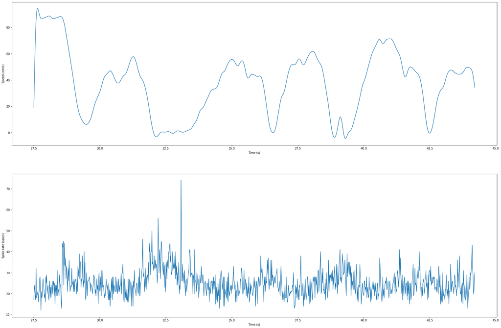

```python
fig, ax = plt.subplots(2,1,figsize=(30, 20))

ax[0].plot(running_timestamps[:1000],running_speed[:1000])
ax[0].set_ylabel('Speed (cm/s)')
ax[0].set_xlabel('Time (s)')

ax[1].plot(running_timestamps[:1000],spike_counts[:1000])
ax[1].set_ylabel('Spike rate (spk/s)')
ax[1].set_xlabel('Time (s)')
```

Plotting the running speed and averaged neural activity side-by-side looks promising! You can somewhat see that the neural data has peaks about where the running data has troughs, so these two data may be inversely correlated.

```python
# want to increase our bin size since spike rate is very discretized at small bin sizes

# first, average running speed over several adjacent bins
bins_to_average = 25
smooth_running_timestamps = running_timestamps[::bins_to_average]
smooth_running_speed = np.mean(np.array(running_speed[:(len(smooth_running_timestamps)-1)*bins_to_average]).reshape(-1, bins_to_average), axis=1)

# then get average firing rates over same timestamps
smooth_counts = np.zeros((len(good_units),len(smooth_running_timestamps)-1))
for ind, unit in enumerate(good_units.index):
    unit_spiketimes = good_spiketimes[unit]
    smooth_counts[ind,:] = np.histogram(unit_spiketimes,smooth_running_timestamps)[0]

# Add all the spike rates to get multiunit activity
smooth_spike_counts = np.mean(smooth_counts, axis=0)
avg_spike_rates = smooth_spike_counts/np.diff(smooth_running_timestamps)
```

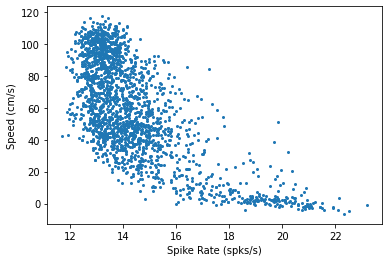

```python
fig, ax = plt.subplots(1,1)

ax.plot(avg_spike_rates[:2000],smooth_running_speed[:2000], 'o', ms=2)
ax.set_ylabel('Speed (cm/s)')
ax.set_xlabel('Spike Rate (spks/s)')
```

When we average spiking and running speed over larger time scales, you see a reasonably clear negative correlation. We will attempt to quantify how strong this correlation is.

You may notice that thinking of running speed as continuous may also not be the "best" way to go about analysis; perhapse we should consider it as a binary (running v. not running) variable. We will go over how to build this type of model in the classification tutorial!

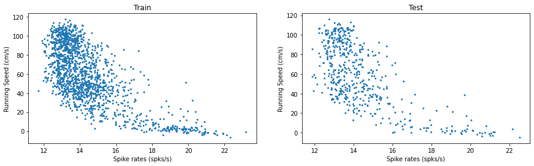

```python
spikes_train, spikes_test, run_train, run_test = \
train_test_split(avg_spike_rates[:2000], smooth_running_speed[:2000], train_size=0.75, random_state=rand_seed)

fig, ax = plt.subplots(1,2, figsize=(15,4))
ax[0].plot(spikes_train, run_train, 'o', ms=2)
ax[1].plot(spikes_test, run_test, 'o', ms=2)

ax[0].set_title('Train')
ax[1].set_title('Test')

for i in range(2):
    ax[i].set_xlabel('Spike rates (spks/s)')
    ax[i].set_ylabel('Running Speed (cm/s)')
```

Remember, we don't need a separate validation set if we make use of the cross validation tools!

Try changing the bin numbers in the cell below.

```python
lr_order1 = LinearRegression()
lr_order1.fit(spikes_train.reshape(-1, 1), run_train)
```

```
LinearRegression()
```

```python
lr_order1.intercept_, lr_order1.coef_
```

```
(219.18922224308608, array([-11.11233842]))
```

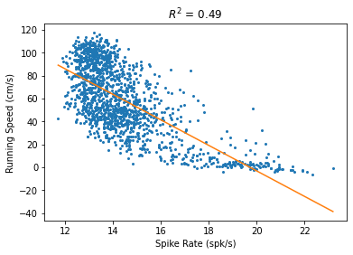

```python
x_bins = np.linspace(np.min(spikes_train), np.max(spikes_train), 100)

fig, ax = plt.subplots()
ax.plot(spikes_train, run_train, 'o', ms=2)
ax.plot(x_bins, lr_order1.predict(x_bins.reshape(-1,1)))
ax.set_xlabel('Spike Rate (spk/s)')
ax.set_ylabel('Running Speed (cm/s)')

R2 = lr_order1.score(spikes_train.reshape(-1,1), run_train)
ax.set_title(f'$R^2$ = {R2:0.2f}')
```

```python
max_order = 9

lr_list = [LinearRegression() for ind in range(max_order)]
for ind, lr in enumerate(lr_list):
    spikes_nth_order = nth_polynomial(spikes_train, ind+1)
    lr.fit(spikes_nth_order, run_train)
```

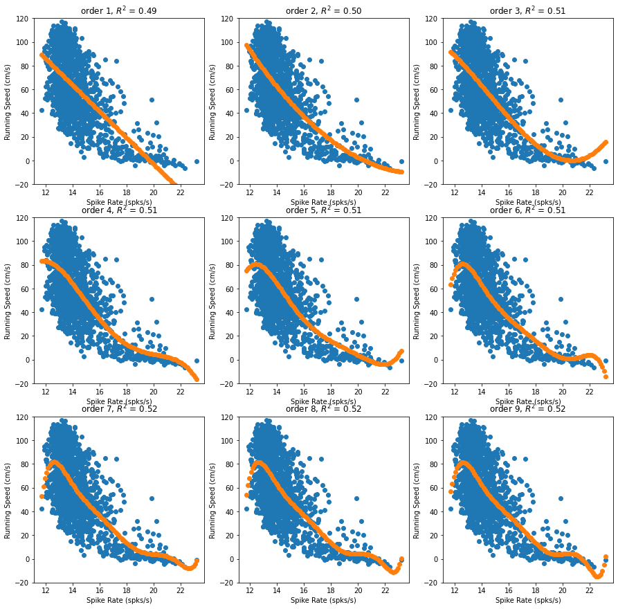

```python
fig, ax = plt.subplots(3,3, figsize=(15,15))

for ind, lr in enumerate(lr_list):
    xi = ind%3
    yi = ind//3
    x_nth_order = nth_polynomial(x_bins, ind+1)
    ax[yi, xi].plot(spikes_train, run_train, 'o')
    ax[yi, xi].plot(x_bins, lr.predict(x_nth_order),'o')
    ax[yi, xi].set_xlabel('Spike Rate (spks/s)')
    ax[yi, xi].set_ylabel('Running Speed (cm/s)')
    ax[yi, xi].set_ylim((-20, 120))

    spikes_nth = nth_polynomial(spikes_train, ind+1)
    R2 = lr.score(spikes_nth, run_train)
    ax[yi, xi].set_title(f'order {ind+1}, $R^2$ = {R2:0.2f}')
```

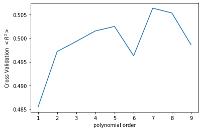

```python
folds = KFold(n_splits=10)

scores = np.zeros_like(lr_list)

for ind, regression in enumerate(lr_list):
    scores_temp = []
    for train, test in folds.split(spikes_train):
        x_nth = nth_polynomial(spikes_train[train], ind+1)
        regression.fit(x_nth, run_train[train])
        x_nth = nth_polynomial(spikes_train[test], ind+1)
        scores_temp.append(regression.score(x_nth, run_train[test]))
    scores[ind] = np.mean(scores_temp)


fig, ax = plt.subplots()
ax.plot(range(1,max_order+1),scores)
ax.set_ylabel('Cross Validation $<R^2>$')
ax.set_xlabel('polynomial order')
# ax.set_ylim(-0.25, 0.25)
```

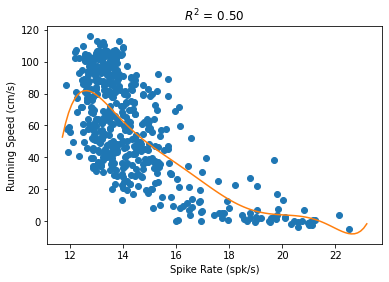

```python
best_model_index = np.argmax(scores)
regression_best = lr_list[best_model_index]
x_nth = nth_polynomial(spikes_train, best_model_index+1)
regression_best.fit(x_nth, run_train)

fig, ax = plt.subplots()
ax.plot(spikes_test, run_test, 'o')
x_nth = nth_polynomial(x_bins, best_model_index+1)
ax.plot(x_bins, regression_best.predict(x_nth))
ax.set_ylabel('Running Speed (cm/s)')
ax.set_xlabel('Spike Rate (spk/s)')

x_nth = nth_polynomial(spikes_test, best_model_index+1)
R2 = regression_best.score(x_nth, run_test)

ax.set_title(f'$R^2$ = {R2:0.2f}')
```

**Exercise 1: Remember, the training set can be multi-dimensional! Try using a matrix of spike rates for every neuron as your training data, rather than the average spike rate across all neurons. How does it do at predicting running speed over time? Plotting the predicted running speed vs actual running speed to find out on some held out data.**

- 1.1: For the spiking training data, use a matrix storing the firing rate (or spike counts) for each neuron at each time bin
- 1.2: Determine the best model using some form of cross-validation
- 1.3: Plot the predicted running speed vs. actual running speed to gauge how well your model performed

```
(-20.0, 130.0)
```

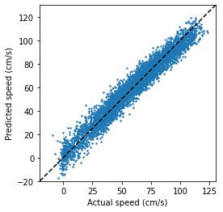

```python
# pass all the individual neurons as the training data instead of the average

spikes_train, spikes_test, run_train, run_test = train_test_split(smooth_counts.T, smooth_running_speed, train_size=0.75)

LR = LinearRegression()
LR.fit(spikes_train,run_train)
run_hat = LR.predict(spikes_test)

fig, ax = plt.subplots()

ax.scatter(run_test,run_hat, s=2)
ax.set_aspect('equal')
ax.set_ylabel('Predicted speed (cm/s)')
ax.set_xlabel('Actual speed (cm/s)')

ax.plot([-50,200],[-50,200], 'k--')
ax.set_xlim((-20, 130))
ax.set_ylim((-20,130))
```

## Cross correlation

Recall that in a regression problem, we are given $N$ pairs of data points $(\vec{x}_i, y_i)$ and attempt to fit a function such that $f(\vec{x}_i)\approx y_i$. When we constructed our data set such that the $\vec{x}_i$ were the spiking data at each time point and the $y_i$ the running speed over the same time period, we made a major assumption: that spiking in MRN is predictive of running *at the same point in time*. However, being neuroscientists, we know that this is likely not the case: spiking is more likely to either happen ahead of behavior (if it is driving behavior) or after behavior (if it is responding to behavior). We may be able to find better correlations if we shift one of the inputs in time.

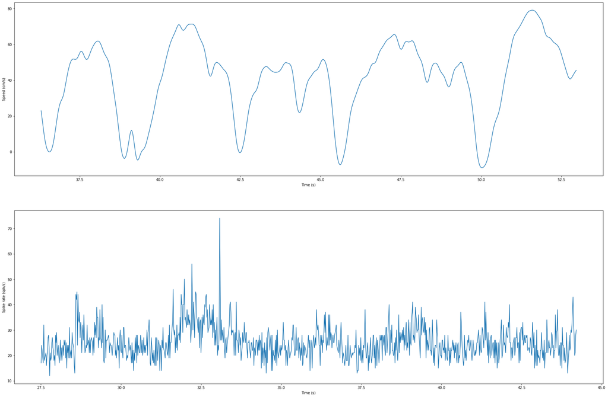

```python
# shift the running input back to see if it correlated better with spiking
bins_to_shift = 25

fig, ax = plt.subplots(2,1,figsize=(30, 20))

ax[0].plot(running_timestamps[500+bins_to_shift:1500+bins_to_shift],running_speed[500+bins_to_shift:1500+bins_to_shift])
ax[0].set_ylabel('Speed (cm/s)')
ax[0].set_xlabel('Time (s)')

ax[1].plot(running_timestamps[:1000],spike_counts[:1000])
ax[1].set_ylabel('Spike rate (spk/s)')
ax[1].set_xlabel('Time (s)')
```

This looks promising! Let's see how well these correlate now on our smoothed traces.

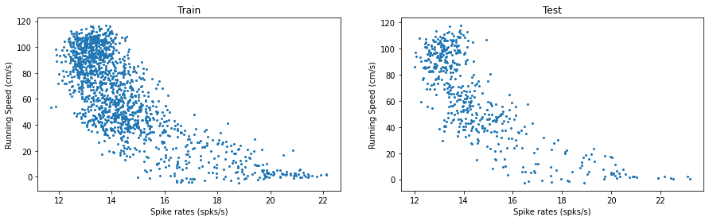

```python
bins_to_shift_smoothed = bins_to_shift//bins_to_average

spikes_train, spikes_test, run_train, run_test = \
train_test_split(avg_spike_rates[500:2500], smooth_running_speed[500+bins_to_shift_smoothed:2500+bins_to_shift_smoothed], train_size=0.75, random_state=rand_seed)

fig, ax = plt.subplots(1,2, figsize=(15,4))
ax[0].plot(spikes_train, run_train, 'o', ms=2)
ax[1].plot(spikes_test, run_test, 'o', ms=2)

ax[0].set_title('Train')
ax[1].set_title('Test')

for i in range(2):
    ax[i].set_xlabel('Spike rates (spks/s)')
    ax[i].set_ylabel('Running Speed (cm/s)')
```

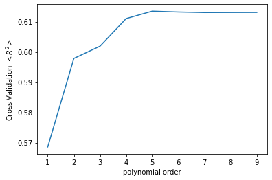

```python
max_order = 9
lr_list = [LinearRegression() for ind in range(max_order)]

folds = KFold(n_splits=10)

scores = np.zeros_like(lr_list)

for ind, regression in enumerate(lr_list):
    scores_temp = []
    for train, test in folds.split(spikes_train):
        x_nth = nth_polynomial(spikes_train[train], ind+1)
        regression.fit(x_nth, run_train[train])
        x_nth = nth_polynomial(spikes_train[test], ind+1)
        scores_temp.append(regression.score(x_nth, run_train[test]))
    scores[ind] = np.mean(scores_temp)


fig, ax = plt.subplots()
ax.plot(range(1,max_order+1),scores)
ax.set_ylabel('Cross Validation $<R^2>$')
ax.set_xlabel('polynomial order')
```

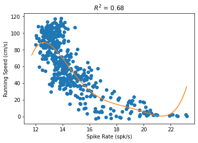

```python
best_model_index = np.argmax(scores)
regression_best = lr_list[best_model_index]
x_nth = nth_polynomial(spikes_train, best_model_index+1)
regression_best.fit(x_nth, run_train)

fig, ax = plt.subplots()
ax.plot(spikes_test, run_test, 'o')
x_nth = nth_polynomial(x_bins, best_model_index+1)
ax.plot(x_bins, regression_best.predict(x_nth))
ax.set_ylabel('Running Speed (cm/s)')
ax.set_xlabel('Spike Rate (spk/s)')

x_nth = nth_polynomial(spikes_test, best_model_index+1)
R2 = regression_best.score(x_nth, run_test)

ax.set_title(f'$R^2$ = {R2:0.2f}')
```

Success! We found a better fit! But can we do even better?

**Exercise 2: Try several different time lags and see what leads to the best correlation between spiking and running.**

- 2.1: Create a list of time lags to test (or numbers of bins to shift). These can be positive or negative!
- 2.2: Loop over these lags and determine $R^2$ values for each
- 2.3: Plot the best model you found in this way

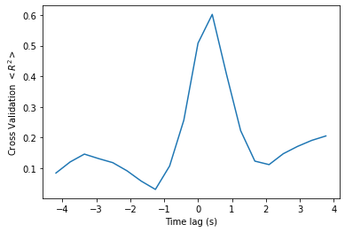

```python
# what is the best time lag to use to correlate these responses?

# just using the polynomial order that worked best before
order = best_model_index
bin_lags = np.arange(-10, 10)

# doing a BAD THING by assuming all the running timestamps are equally spaced
# but they are close to the same so it'll do for now
bin_length = np.mean(np.diff(running_timestamps))
bin_length = bin_length*bins_to_average
time_lags = bin_lags * bin_length


lr_list = [LinearRegression() for ind in range(len(time_lags))]
folds = KFold(n_splits=10)
scores = np.zeros_like(lr_list)

for ind, regression in enumerate(lr_list):
    # have to do the splitting each time since the data itself changes
    spikes_train, spikes_test, run_train, run_test = \
        train_test_split(avg_spike_rates[500:2500], smooth_running_speed[500+bin_lags[ind]:2500+bin_lags[ind]], train_size=0.75, random_state=rand_seed)
    scores_temp = []
    for train, test in folds.split(spikes_train):
        x_nth = nth_polynomial(spikes_train[train], order)
        regression.fit(x_nth, run_train[train])
        x_nth = nth_polynomial(spikes_train[test], order)
        scores_temp.append(regression.score(x_nth, run_train[test]))
    scores[ind] = np.mean(scores_temp)

fig, ax = plt.subplots()
ax.plot(time_lags,scores)
ax.set_ylabel('Cross Validation $<R^2>$')
ax.set_xlabel('Time lag (s)')
```

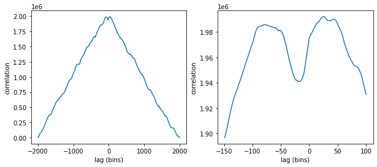

```python
# you can also do this more directly with scipy's cross-correlation function!
from scipy.signal import correlate
correlation = correlate(spike_counts[500:2500], running_speed[500:2500])
np.argmax(correlation)
len(correlation)

bin_lags = range(-1999, 2000)
fig, ax = plt.subplots(1,2, figsize=(10,4))
ax[0].plot(bin_lags, correlation)
ax[0].set_ylabel('correlation')
ax[0].set_xlabel('lag (bins)')
ax[1].plot(bin_lags[1850:2100], correlation[1850:2100])
ax[1].set_ylabel('correlation')
ax[1].set_xlabel('lag (bins)')
```

While these models can do better, they often don't capture the full richness of the neural response, as behavior isn't determined by a activity in a single point in time, but evolves over time and takes activity over many time points into account. You can better model this with a GLM (tutorial coming soon!)

However, analyses like these can still be useful to identify the relation between two variables in time (e.g. is neural activity driving running, or following running?)